# European repository landscape - visualizations

Niek Van Wettere (https://orcid.org/0000-0002-9455-368X)

# 1 Introduction

In this document, the European repository landscape is examined using different visualizations. I focus on (1) repository types (e.g. institutional, discipline-specific etc.) and (2) usage statistics pertaining to repositories.

```r
# load packages
.libPaths("C:/R/library") # load R packages: the path has to be adjusted to where the packages are saved
library(readxl, quietly = T); library(dplyr, quietly = T); library(ggplot2, quietly = T); library(stringr, quietly = T)
```

The raw data is collected from re3data and Datacite. See below for the type of content.

```r
# read data from different source files
data_re3data<-read_excel("Raw_data/20220114_output_re3data_2.xlsx") # from re3data
head(data_re3data)
```

| ID | name | link | country | repositoryURL | type | subject_first | subject | institutionName | institutionType | pidSystem |
| --- | --- | --- | --- | --- | --- | --- | --- | --- | --- | --- |
| r3d100010696 | Global Catalogue of Microorganisms | https://www.re3data.org/api/beta/repository/r3d100010696 | Belgium | http://gcm.wfcc.info/ | disciplinary | 2 Life Sciences | 2 Life Sciences+204 Microbiology, Virology and Immunology+21 Biology+22 Medicine | Chinese Academy of Sciences, Institute of Microbiology, Information Network Center+World Federation for Culture Collections | non-profit | none |
| r3d100011659 | Satellite Application Facility on Climate Monitoring | https://www.re3data.org/api/beta/repository/r3d100011659 | Belgium | https://www.cmsaf.eu/EN/Home/home_node.html | disciplinary+institutional | 3 Natural Sciences | 3 Natural Sciences+313 Atmospheric Science and Oceanography+34 Geosciences (including Geography) | Deutscher Wetterdienst+Eumetsat+European Centre for Medium Weather Forecast+Royal Meteorological Institute of Belgium | non-profit | DOI |
| r3d100011648 | AHEAD | https://www.re3data.org/api/beta/repository/r3d100011648 | Belgium | https://www.emidius.eu/AHEAD/ | disciplinary | 3 Natural Sciences | 3 Natural Sciences+314 Geology and Palaeontology+31401 Geology and Palaeontology+315 Geophysics and Geodesy+34 Geosciences (including Geography) | Bureau de Recherches Géologiques et Minières+EPOS+Institut Cartogràfic i Geològic de Catalunya+Institut de radioprotection et de sûreté nucléaire+Institute of Engineering Seismology and Earthquake Eng… | non-profit+commercial | DOI |
| r3d100011040 | MultiDark Database | https://www.re3data.org/api/beta/repository/r3d100011040 | Belgium | http://www.multidark.org// | disciplinary | 3 Natural Sciences | 3 Natural Sciences+311 Astrophysics and Astronomy+32 Physics | AstroGrid-D+German Astrophysical Virtual Observatory+Leibniz-Institut für Astrophysik Potsdam+Multimessenger Approach for Dark Matter Detection+PRACE | non-profit | other |
| r3d100011460 | SPECTR-W3 | https://www.re3data.org/api/beta/repository/r3d100011460 | Belgium | http://spectr-w3.snz.ru/index.phtml | disciplinary | 3 Natural Sciences | 3 Natural Sciences+303 Physical and Theoretical Chemistry+30301 Physical Chemistry of Molecules, Interfaces and Liquids - Spectroscopy, Kinetics+308 Optics, Quantum Optics and Physics of Atoms, Molecu… | Aix-Marseille University, Physics of Ionic and Molecular Interactions+Czech Technical University in Prague, Faculty of Nuclear Sciences and Physical Engineering+GSI Helmholtzzentrum für Schwerionenfor… | non-profit | none |
| r3d100011724 | EUREF Permanent Network | https://www.re3data.org/api/beta/repository/r3d100011724 | Belgium | http://www.epncb.oma.be/ | disciplinary | 3 Natural Sciences | 3 Natural Sciences+313 Atmospheric Science and Oceanography+315 Geophysics and Geodesy+317 Geography+34 Geosciences (including Geography) | EUREF+International Association of Geodesy+Royal Observatory of Belqium, Global Navigation Satellite Systems Research Group | non-profit | none |

```r
data_DataCite_repo_names<-read_excel("Raw_data/20220112_output_DataCite_clients.xlsx") # from DataCite
head(data_DataCite_repo_names)
```

| repo_name | repo_symbol | repo_url |
| --- | --- | --- |
| 'Health Monitoring' Research Data Centre at the Robert Koch Institute | GESIS.RKI | https://www.rki.de/DE/Content/Forsch/FDZ/FDZ_node.html |
| 027.7 - Zeitschrift für Bibliothekskultur | ETHZ.UBASOJS | https://0277.ch/ |
| 4TU.ResearchData | DELFT.DATA4TU | https://researchdata.4tu.nl/en/home/ |
| ]a[repository | AKBILD.AREPOSITORY | https://repository.akbild.ac.at |
| Aalborg University Library | DK.AAU | NA |
| Aalto University | CSC.AALTO | NA |

```r
data_DataCite_usage<-read_excel("Raw_data/20220112_output_DataCite_depo_per_repo_2021.xlsx") # from DataCite
colnames(data_DataCite_usage)[1] <- "repo_symbol"
head(data_DataCite_usage)
```

| repo_symbol | total_depo_2021 | count_datasets | count_software |
| --- | --- | --- | --- |
| GESIS.RKI | 2 | NA | NA |
| ETHZ.UBASOJS | 0 | error | error |
| DELFT.DATA4TU | 1882 | 1655 | 6 |
| AKBILD.AREPOSITORY | 45 | NA | NA |
| DK.AAU | 246 | 18 | NA |
| CSC.AALTO | 26 | 3 | NA |

# 2 Re3data: institutional vs. discipline-specific repositories

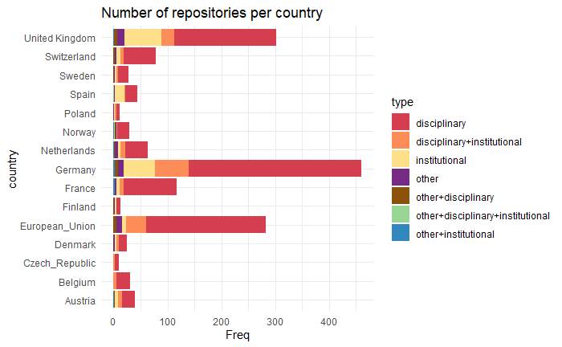

```r
# plot_1
repo_per_country <- as.data.frame(table(data_re3data$country))
restricted_country_list<-repo_per_country[repo_per_country$Freq > 10, ]$Var1
data_re3data_restricted<-filter(data_re3data, as.character(country) %in% as.character(restricted_country_list))
table_re3data<-as.data.frame(table(as.character(data_re3data_restricted$country), as.character(data_re3data_restricted$type)))
colnames(table_re3data)<-c("country", "type", "Freq")
table_re3data<-filter(table_re3data, type != "")
(repo_plot<-ggplot(table_re3data, aes(x=country, y=Freq, fill = type)) + geom_bar(stat = "identity") + theme_minimal() + coord_flip() + ggtitle("Number of repositories per country") + scale_fill_manual(values = c("disciplinary" = "#d53e4f", "disciplinary+institutional" = "#fc8d59", "institutional" = "#fee08b", "other" = "#762a83", "other+disciplinary" = "#8c510a", "other+disciplinary+institutional" = "#99d594", "other+institutional" = "#3288bd")))
```

Now, the same type of graph is plotted, but this time, the relevant disciplines are also taken into account.

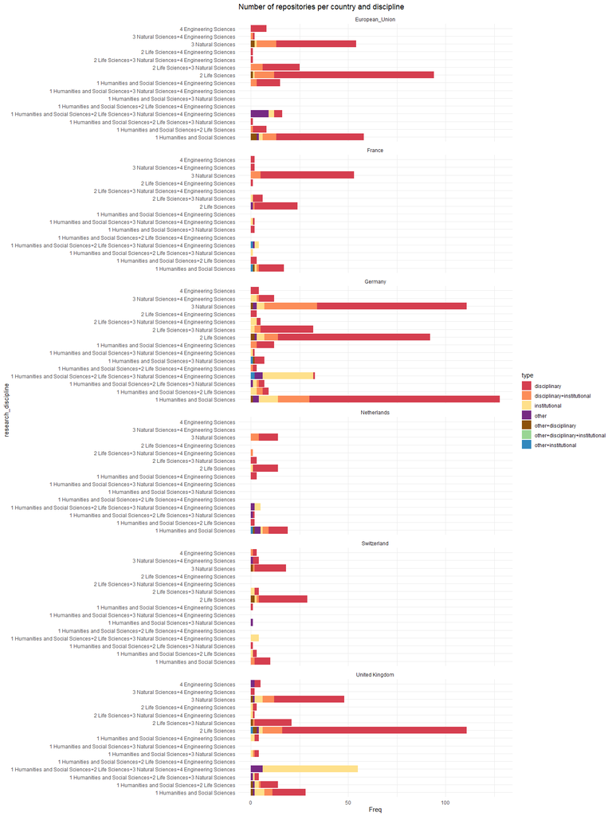

```r
# plot_2
repo_per_country <- as.data.frame(table(data_re3data$country))
restricted_country_list<-repo_per_country[repo_per_country$Freq > 50, ]$Var1
data_re3data_restricted<-filter(data_re3data, as.character(country) %in% as.character(restricted_country_list))
for (i in (1:nrow(data_re3data_restricted))) {  # eliminate doubles in "subject first" column
  temporary<-str_split(data_re3data_restricted$subject_first[i], "\\+ ?")
  temporary_unique <- unique(temporary[[1]])
  data_re3data_restricted$subject_first[i]<-paste(temporary_unique, collapse="+")
}
table_re3data_2<-as.data.frame(table(as.character(data_re3data_restricted$subject_first), as.character(data_re3data_restricted$country), as.character(data_re3data_restricted$type)))
colnames(table_re3data_2)<-c("research_discipline", "country", "type", "Freq")
table_re3data_2<-filter(table_re3data_2, type != "" & research_discipline != "NA" & Freq != 0 & research_discipline != "")
(repo_plo_2<-ggplot(table_re3data_2, aes(x=research_discipline, y=Freq, fill = type)) + geom_bar(stat = "identity") + theme_minimal() + coord_flip() + ggtitle("Number of repositories per country and discipline") + facet_wrap(~ country, ncol = 1)) + scale_fill_manual(values = c("disciplinary" = "#d53e4f", "disciplinary+institutional" = "#fc8d59", "institutional" = "#fee08b", "other" = "#762a83", "other+disciplinary" = "#8c510a", "other+disciplinary+institutional" = "#99d594", "other+institutional" = "#3288bd"))
```

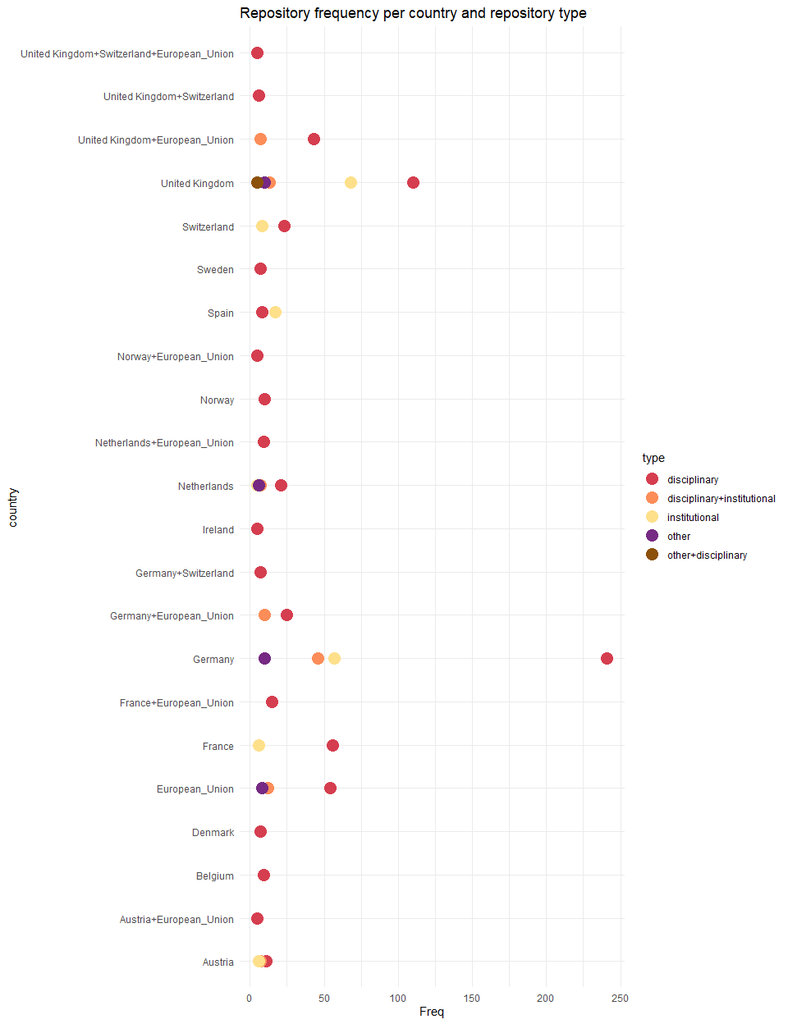

```r
# some repositories occur more than once in the data
unique_ids <- unique(data_re3data$ID)
diff_repo <- length(data_re3data$ID) - length(unique_ids) # difference between total number of repo and total number of unique repo
doubles <- list()  # locate all the doubles in the data
doubles_without_first <- list()
for (i in unique_ids) {
  loc <- which(data_re3data$ID == i)

  if (length(loc) >= 2) {
    doubles<-append(doubles, list(loc))
    doubles_without_first <- append(doubles_without_first, list(loc[2:length(loc)]))
  }}
re3data_limited<-data_re3data
re3data_limited$country <- as.character(re3data_limited$country)
for (j in 1:length(doubles)) {
  countries <- paste(as.character(data_re3data[doubles[[j]],]$country), collapse = "+")  # merge countries for same repository

  re3data_limited[doubles[[j]][1],4] <- countries
  }
to_be_removed <- unlist(doubles_without_first)
re3data_limited <- re3data_limited[-to_be_removed, ]
disc_instit_data<-as.data.frame(table(as.character(re3data_limited$country), as.character(re3data_limited$type)))
disc_instit_data_2<-filter(disc_instit_data, Freq != 0 & Var2 != "")
colnames(disc_instit_data_2)<-c("country", "type", "Freq")
disc_instit_data_3<-filter(disc_instit_data_2, Freq >= 5) # select only most frequent ones to plot
ggplot(disc_instit_data_3, aes(x=country, y=Freq, color = type)) + geom_point(size = 5) + theme_minimal() + coord_flip() + ggtitle("Repository frequency per country and repository type") + scale_color_manual(values = c("disciplinary" = "#d53e4f", "disciplinary+institutional" = "#fc8d59", "institutional" = "#fee08b", "other" = "#762a83", "other+disciplinary" = "#8c510a"))
```

# 3 Repositories according to usage statistics

Secondly, European research data repositories are ranked according to how much they were used in publication year 2021, based on metadata from DataCite. The first plot below ranks the repositories taking into account all types of submissions.

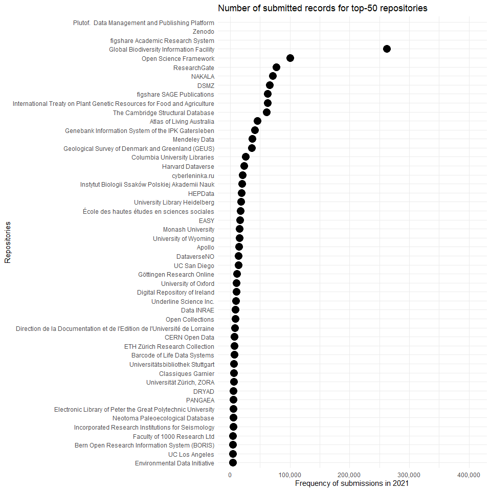

```r
DataCite_new <- merge(data_DataCite_usage, data_DataCite_repo_names, by = "repo_symbol", all = TRUE)
DataCite_new_2 <- DataCite_new[order(-DataCite_new$total_depo_2021),]
DataCite_new_3 <- DataCite_new_2[1:50,]
require(scales)
ggplot(DataCite_new_3, aes(x=reorder(repo_name, total_depo_2021), y=total_depo_2021)) + geom_point(size = 5) + theme_minimal() + coord_flip() + ggtitle("Number of submitted records for top-50 repositories") + xlab("Repositories") + ylab("Frequency of submissions in 2021") + scale_y_continuous(labels = scales::comma, limits = c(0,410000))
```

The tabular data underlying the plot above:

```r
(DataCite_new_3)
```

|  | repo_symbol | total_depo_2021 | count_datasets | count_software | repo_name | repo_url |
| --- | --- | --- | --- | --- | --- | --- |
| 539 | ESTDOI.BIO | 1676441 | 1676435 | NA | Plutof. Data Management and Publishing Platform | NA |
| 282 | CERN.ZENODO | 425278 | 56134 | 75054 | Zenodo | https://zenodo.org/ |
| 711 | FIGSHARE.ARS | 414346 | 136649 | 3826 | figshare Academic Research System | http://figshare.com/ |
| 801 | GBIF.GBIF | 262638 | 262632 | NA | Global Biodiversity Information Facility | https://www.gbif.org/ |
| 350 | COS.OSF | 100648 | NA | NA | Open Science Framework | https://osf.io/ |
| 1788 | RG.RG | 77416 | 7191 | NA | ResearchGate | https://www.researchgate.net/search/data |
| 1053 | INIST.HUMANUM | 70860 | 534 | 22 | NAKALA | https://nakala.fr |
| 2424 | ZBMED.DSMZ | 66095 | 66095 | NA | DSMZ | https://www.dsmz.de/ |
| 762 | FIGSHARE.SAGE | 62840 | 3316 | 6 | figshare SAGE Publications | NA |
| 666 | FAO.ITPGRFA | 62792 | NA | NA | International Treaty on Plant Genetic Resources for Food and Agriculture | https://ssl.fao.org/glis |

[output cut: 40 more lines]

Next, the type of submission is restricted to "dataset" in the plot below.

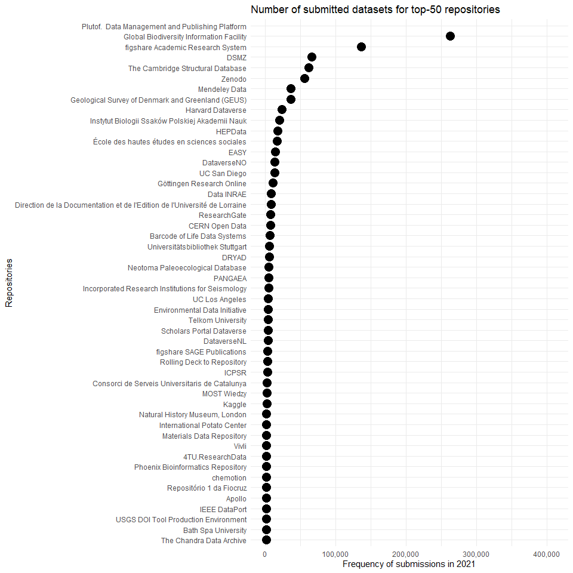

```r
DataCite_new_dataset_count <- filter(DataCite_new, count_datasets != "NA" & count_datasets != "error")
DataCite_new_dataset_count$count_datasets <- as.numeric(DataCite_new_dataset_count$count_datasets)
DataCite_new_dataset_count <- DataCite_new_dataset_count[order(-DataCite_new_dataset_count$count_datasets),]
DataCite_new_dataset_count_2 <- DataCite_new_dataset_count[1:50,]
require(scales)
ggplot(DataCite_new_dataset_count_2, aes(x=reorder(repo_name, count_datasets), y=count_datasets)) + geom_point(size = 5) + theme_minimal() + coord_flip() + ggtitle("Number of submitted datasets for top-50 repositories") + xlab("Repositories") + ylab("Frequency of submissions in 2021") + scale_y_continuous(labels = scales::comma, limits = c(0,410000))
```

The tabular data underlying the plot above:

```r
(DataCite_new_dataset_count_2)
```

|  | repo_symbol | total_depo_2021 | count_datasets | count_software | repo_name | repo_url |
| --- | --- | --- | --- | --- | --- | --- |
| 244 | ESTDOI.BIO | 1676441 | 1676435 | NA | Plutof. Data Management and Publishing Platform | NA |
| 320 | GBIF.GBIF | 262638 | 262632 | NA | Global Biodiversity Information Facility | https://www.gbif.org/ |
| 265 | FIGSHARE.ARS | 414346 | 136649 | 3826 | figshare Academic Research System | http://figshare.com/ |
| 713 | ZBMED.DSMZ | 66095 | 66095 | NA | DSMZ | https://www.dsmz.de/ |
| 136 | CCDC.CSD | 61310 | 61310 | NA | The Cambridge Structural Database | https://www.ccdc.cam.ac.uk/solutions/csd-system/components/csd/ |
| 153 | CERN.ZENODO | 425278 | 56134 | 75054 | Zenodo | https://zenodo.org/ |
| 94 | BL.MENDELEY | 36611 | 36611 | NA | Mendeley Data | https://data.mendeley.com/ |
| 223 | DK.GEUS | 36342 | 36342 | NA | Geological Survey of Denmark and Greenland (GEUS) | NA |
| 323 | GDCC.HARVARD-DV | 23160 | 23160 | NA | Harvard Dataverse | https://dataverse.harvard.edu/ |
| 509 | PSNC.IBSPAN | 19758 | 19758 | NA | Instytut Biologii Ssaków Polskiej Akademii Nauk | https://dataverse.openforestdata.pl/ |

[output cut: 40 more lines]